```python
import pandas as pd
import numpy as np
from datetime import datetime
import matplotlib.dates as mdates
import matplotlib.pyplot as plt
%matplotlib inline
```

```python
ConstDf = pd.read_csv('ConstructionTimeSeriesDatav2.csv')
```

# Private Construction

Plotting the data will help to determine if it is linear or not.

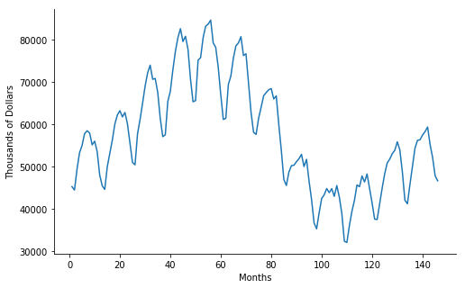

```python
#Creating a figure
fig, ax = plt.subplots()
fig.set_size_inches(8,5)

#Plotting the data
ax.plot(ConstDf['Month'], ConstDf['Private Construction'])
ax.set_ylabel('Thousands of Dollars')
ax.set_xlabel('Months')
ax.spines['right'].set_visible(False)
ax.spines['top'].set_visible(False)
plt.show()
```

The data appears to be cyclical rather than linear, therefore a moving average column will be made.

```python
ConstDf['MovAvg'] = np.NaN
ConstDf['sqErr'] = np.NaN
# Chaging the DataFrame index to DatetimeIndex data type is required for using one of the functions below
ConstDf.index = pd.DatetimeIndex(freq='m', start=pd.Timestamp(year=2002, month=1, day=31), periods = len(ConstDf['Month']))

window = 12
window = window - window % 2

for i in range(int(window/2),ConstDf.shape[0]-int(window/2)):
    ConstDf.loc[ConstDf.index[i],'MovAvg'] = (0.5*ConstDf.iloc[i - int(window/2)]['Private Construction'] + ConstDf.iloc[i - int(window/2)+1:i + int(window/2)]['Private Construction'].sum() + 0.5*ConstDf.iloc[i + int(window/2)]['Private Construction'])/float(window)

ConstDf['sqErr'] = (ConstDf['Private Construction'] - ConstDf['MovAvg'])**2
ConstDf.dropna(how='any',inplace=True)
```

Plotting the 12-month moving average shows the smoothed data and makes the cycle more obvious.

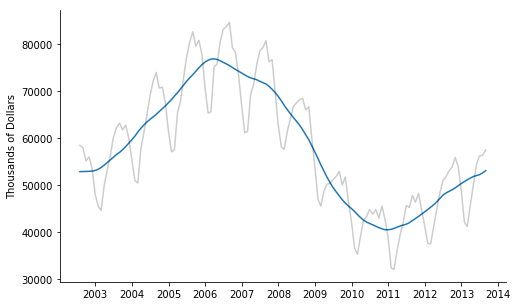

```python
fig,ax = plt.subplots()
fig.set_size_inches(8,5)

ax.plot(ConstDf['MovAvg'],label='Moving Avg')
ax.plot(ConstDf['Private Construction'],label='Private Construction', color='k', alpha=0.2)
ax.set_ylabel('Thousands of Dollars')
ax.xaxis.set_major_locator(mdates.YearLocator())
ax.spines['right'].set_visible(False)
ax.spines['top'].set_visible(False)
plt.show()
```

R1 is found by subtracting the moving average from the actual private construction spending

```python
ConstDf['R1'] = ConstDf['Private Construction'] - ConstDf['MovAvg']
ConstDf['R1Error'] = abs((ConstDf['Private Construction'] - ConstDf['R1'])/ConstDf['Private Construction'])
ConstDf.style.format({
    'MovAvg': '{:.1f}'.format,
    'sqErr': '{:,.1f}'.format,
    'R1': '{:,.1f}'.format,
    'R1Error': '{:,.3f}'.format
})
ConstDf.head()
```

|  | Month | Month-Year | Total Construction | Private Construction | Public Construction | MovAvg | sqErr | R1 | R1Error |
| --- | --- | --- | --- | --- | --- | --- | --- | --- | --- |
| 2002-07-31 | 7 | Jul-02 | 78863 | 58494 | 20369 | 52878.250000 | 3.153665e+07 | 5615.750000 | 0.903994 |
| 2002-08-31 | 8 | Aug-02 | 79460 | 57953 | 21507 | 52892.625000 | 2.560740e+07 | 5060.375000 | 0.912681 |
| 2002-09-30 | 9 | Sep-02 | 76542 | 55157 | 21385 | 52923.666667 | 4.987778e+06 | 2233.333333 | 0.959510 |
| 2002-10-31 | 10 | Oct-02 | 75710 | 56023 | 19687 | 52945.000000 | 9.474084e+06 | 3078.000000 | 0.945058 |
| 2002-11-30 | 11 | Nov-02 | 71362 | 53552 | 17810 | 52994.541667 | 3.107598e+05 | 557.458333 | 0.989590 |

```python
print('Mean Squared Error: ', ConstDf['sqErr'].mean())
```

```
Mean Squared Error:  31701673.583670188
```

Plotting the residuals that are yet to be decomposed

```
Average Residual:  30.595149253731616
```

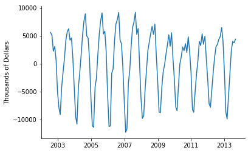

```python
fig,ax = plt.subplots()
ax.plot(ConstDf['R1'])
ax.set_ylabel('Thousands of Dollars')
ax.spines['right'].set_visible(False)
ax.spines['top'].set_visible(False)
print('Average Residual: ', sum(ConstDf['R1'])/len(ConstDf))
```

An autocorrelation analysis detects that there is a cyclical pattern that is repeated every 12 months

```python
maxCorr = 0.0
period = np.NaN
for i in range(1,37):
    corr = ConstDf['R1'].autocorr(lag=i)
    print('Correlation, lag ',i,'   ',corr)
    if corr > maxCorr:
        maxCorr = corr
        period = i
print('period = ',period,'     Maximum Correlation = ',maxCorr)
```

```
Correlation, lag  1     0.8012201439941184
Correlation, lag  2     0.4046160901273205
Correlation, lag  3     -0.06681918914657627
Correlation, lag  4     -0.46817065394656976
Correlation, lag  5     -0.7334595961596322
Correlation, lag  6     -0.8453947574465044
Correlation, lag  7     -0.7277714550926001
Correlation, lag  8     -0.45905643208796504
Correlation, lag  9     -0.06590030685316585
Correlation, lag  10     0.38876557877044954
Correlation, lag  11     0.7742521355064202
Correlation, lag  12     0.9718794492320808
Correlation, lag  13     0.7939675179405197
Correlation, lag  14     0.42010968825364053
Correlation, lag  15     -0.04354347496856092
Correlation, lag  16     -0.442926503934742
Correlation, lag  17     -0.7143108783050305
Correlation, lag  18     -0.8348740788345422
Correlation, lag  19     -0.7220461363177707
Correlation, lag  20     -0.46345532637190096
Correlation, lag  21     -0.07542839840758336
Correlation, lag  22     0.3757544697881611
Correlation, lag  23     0.7577865456995792
Correlation, lag  24     0.9501687246722736
Correlation, lag  25     0.7791292709751689
Correlation, lag  26     0.41255871809160327
Correlation, lag  27     -0.043743995698720124
Correlation, lag  28     -0.4315886140397296
Correlation, lag  29     -0.691204741968494
Correlation, lag  30     -0.8066609657795124
Correlation, lag  31     -0.7036163685792343
Correlation, lag  32     -0.46447140443692114
Correlation, lag  33     -0.09460912838857628
Correlation, lag  34     0.3434182145863765
Correlation, lag  35     0.7246677936850109
Correlation, lag  36     0.9264044250381518
period =  12      Maximum Correlation =  0.9718794492320808
```

Each individual 12-month cycle within the time series is plotted along with an average of all of the cycles

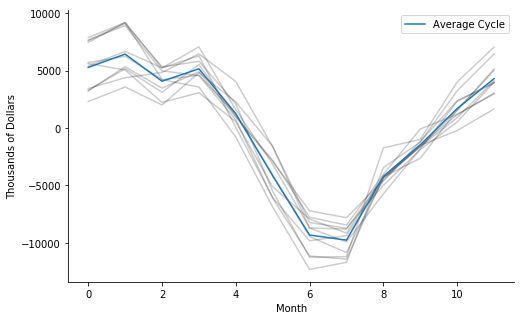

```python
cycleLen = period
numCycles = int(len(ConstDf)/cycleLen + 0.5)
cycles = [ConstDf.iloc[range(i*period,min((i+1)*period,len(ConstDf)))]['R1'] for i in range(numCycles)]
ptsInCycles = [ConstDf.iloc[range(i,len(ConstDf['R1']),period)]['R1'].tolist() for i in range(period)]
avg = [sum(pts)/len(pts) for pts in ptsInCycles]

fig,ax = plt.subplots()
fig.set_size_inches(8,5)

for i in range(len(cycles)):
    ax.plot(cycles[i].values,label='Cycle '+str(i),c='k', alpha=0.2)
AvgCyc = ax.plot(avg,label='Average Cycle')
ax.set_xlabel('Month')
ax.set_ylabel('Thousands of Dollars')
ax.spines['right'].set_visible(False)
ax.spines['top'].set_visible(False)
ax.legend(handles=AvgCyc)
```

A value for the cyclicality is computed and then plotted alongside $R1$

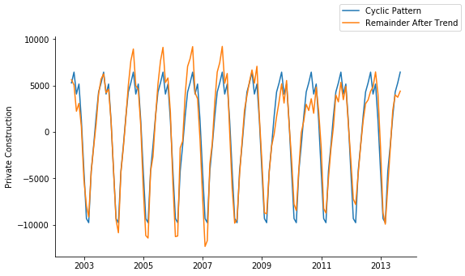

```python
cycleLen = period
numCycles = int(len(ConstDf)/cycleLen + 0.5)
ConstDf['C'] = np.NaN   # Creates an empty column for the cyclicality component data
for i in range(len(ConstDf)):
    ConstDf.loc[ConstDf.index[i], 'C'] = avg[i % cycleLen]

fig,ax = plt.subplots()
fig.set_size_inches(8,5)
ax.plot(ConstDf['C'],label='Cyclic Pattern')
ax.plot(ConstDf['R1'],label='Remainder After Trend')
ax.set_ylabel('Private Construction')
ax.spines['right'].set_visible(False)
ax.spines['top'].set_visible(False)
fig.legend()
plt.show()
```

The code cell below does these:

- Computes the remaining residual construction spending to be explained, $R2$, after subtracting the cyclical component, $C \left( m \right)$: this is the $\epsilon \left( m \right)$ in our model.
- Computes the error, $R2$, as a percentage of the demand time series.
- Computes the mathematical model 'fit', composed of the trend and cyclical components: $T\left( m \right) + C\left( m \right)$.
- Plots the fit of the model $T\left( m \right) + C\left( m \right)$ with the original data, $H \left( m \right)$.
- Computes the average absolute error of $R2Error$ of the original demand time series.
- Removes the sqErr column because it is no longer needed

```
Average Error:  0.020585783569537188
            Month Month-Year  Total Construction  Private Construction  \
2002-07-31      7     Jul-02               78863                 58494
2002-08-31      8     Aug-02               79460                 57953
2002-09-30      9     Sep-02               76542                 55157
2002-10-31     10     Oct-02               75710                 56023
2002-11-30     11     Nov-02               71362                 53552
2002-12-31     12     Dec-02               63984                 48023
2003-01-31     13     Jan-03               59877                 45473
2003-02-28     14     Feb-03               58526                 44620
2003-03-31     15     Mar-03               64506                 49996
2003-04-30     16     Apr-03               69638                 53195
2003-05-31     17     May-03               74473                 56286
2003-06-30     18     Jun-03               80377                 60076
2003-07-31     19     Jul-03               82971                 62216
2003-08-31     20     Aug-03               85191                 63234
2003-09-30     21     Sep-03               83841                 61767
2003-10-31     22     Oct-03               83133                 62813
2003-11-30     23     Nov-03               77915                 60115
2003-12-31     24     Dec-03               71050                 55584
2004-01-31     25     Jan-04               64934                 50975
2004-02-29     26     Feb-04               64138                 50449
2004-03-31     27     Mar-04               73238                 57796
2004-04-30     28     Apr-04               78354                 61177
2004-05-31     29     May-04               83736                 65027
2004-06-30     30     Jun-04               89932                 69039
2004-07-31     31     Jul-04               93614                 72170
2004-08-31     32     Aug-04               96164                 74001
2004-09-30     33     Sep-04               92538                 70662
2004-10-31     34     Oct-04               90582                 70856
2004-11-30     35     Nov-04               86394                 67585
2004-12-31     36     Dec-04               77733                 61438
...           ...        ...                 ...                   ...
2011-03-31    111     Mar-11               56536                 36074
2011-04-30    112     Apr-11               61454                 39441
2011-05-31    113     May-11               65814                 42040
2011-06-30    114     Jun-11               72850                 45686
2011-07-31    115     Jul-11               72113                 45258
2011-08-31    116     Aug-11               77104                 47807
2011-09-30    117     Sep-11               75372                 46382
```

[output cut: 199 more lines]

```
2012-08-31  55129.500000
2012-09-30  53110.946970
2012-10-31  54586.026515
2012-11-30  51139.041667
2012-12-31  46195.640152
2013-01-31  41453.522727
2013-02-28  41386.537879
2013-03-31  47311.844697
2013-04-30  50385.011364
2013-05-31  53739.250000
2013-06-30  56539.306818
2013-07-31  57897.701389
2013-08-31  59523.958333

[134 rows x 14 columns]
```

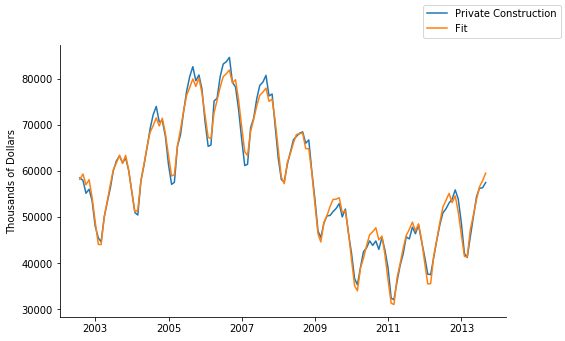

```python
ConstDf['R2'] = ConstDf['R1'] - ConstDf['C']
ConstDf['R2X'] = ConstDf['R2']/ConstDf['Private Construction']
ConstDf['R2Error'] = abs(ConstDf['R2']/ConstDf['Private Construction'])
ConstDf['R2ErrorX'] = ConstDf['R2Error']/ConstDf['Private Construction']
ConstDf['fit'] = ConstDf['MovAvg'] + ConstDf['C']
ConstDf.drop(['sqErr'],axis=1,inplace=True)
print('Average Error: ', sum(ConstDf['R2Error'])/len(ConstDf))
print(ConstDf)

fig,ax = plt.subplots()
fig.set_size_inches(8,5)
ax.plot(ConstDf['Private Construction'],label='Private Construction')
ax.plot(ConstDf['fit'], label = 'Fit')
ax.set_ylabel('Thousands of Dollars')
ax.spines['right'].set_visible(False)
ax.spines['top'].set_visible(False)
fig.legend()
plt.show()
```

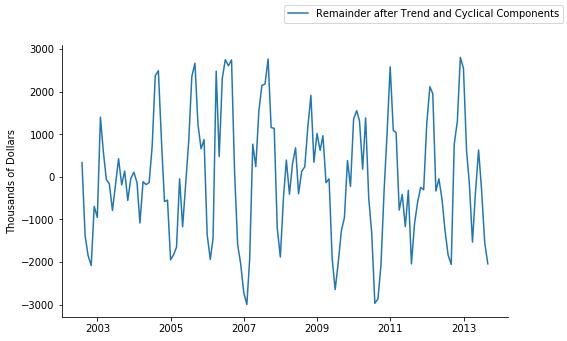

```
Correlation, lag  1     0.6750893529818791
Correlation, lag  2     0.34510105026697396
Correlation, lag  3     -0.04646932554791686
Correlation, lag  4     -0.31441699093452624
Correlation, lag  5     -0.5264754747503062
Correlation, lag  6     -0.5704888079897079
Correlation, lag  7     -0.46742408108255296
Correlation, lag  8     -0.25406846549220946
Correlation, lag  9     -0.05957853056153247
Correlation, lag  10     0.20420845508027602
Correlation, lag  11     0.3982803613194881
Correlation, lag  12     0.5641711274992344
Correlation, lag  13     0.3885919868474464
Correlation, lag  14     0.24867903514059794
Correlation, lag  15     -0.01280108233581247
Correlation, lag  16     -0.17244389682993275
Correlation, lag  17     -0.3198723342230055
Correlation, lag  18     -0.3397289162773922
Correlation, lag  19     -0.24647882498648627
Correlation, lag  20     -0.10355796515376617
Correlation, lag  21     0.00925439780050097
Correlation, lag  22     0.13661370877248732
Correlation, lag  23     0.2361344892661341
Correlation, lag  24     0.25446303473273785
Correlation, lag  25     0.1269784445412423
Correlation, lag  26     0.03518733622890523
Correlation, lag  27     -0.1208330810018835
Correlation, lag  28     -0.12196779445771352
Correlation, lag  29     -0.10429916578864669
Correlation, lag  30     -0.0201001048711322
Correlation, lag  31     0.05769789295902655
Correlation, lag  32     0.07326090158166948
Correlation, lag  33     0.04440990775005338
Correlation, lag  34     -0.010488864707549578
Correlation, lag  35     -0.0375039395934862
Correlation, lag  36     -0.10769274238165621
period =  1      Maximum Correlation =  0.6750893529818791
```

```python
fig,ax = plt.subplots()
fig.set_size_inches(8,5)
ax.plot(ConstDf['R2'],label='Remainder after Trend and Cyclical Components')
ax.set_ylabel('Thousands of Dollars')
ax.spines['right'].set_visible(False)
ax.spines['top'].set_visible(False)
fig.legend()
plt.show()

maxCorr = 0.0
period = np.NaN
for i in range(1,37):
    corr = ConstDf['R2'].autocorr(lag=i)
    print('Correlation, lag ',i,'   ',corr)
    if corr > maxCorr:
        maxCorr = corr
        period = i
print('period = ',period,'     Maximum Correlation = ',maxCorr)
```

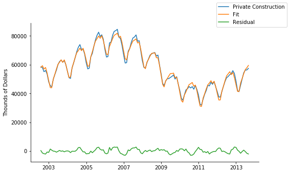

```python
fig,ax = plt.subplots()
fig.set_size_inches(8,5)
ax.plot(ConstDf['Private Construction'],label='Private Construction')
ax.plot(ConstDf['fit'],label='Fit')
ax.plot(ConstDf['R2'],label='Residual')
ax.set_ylabel('Thounds of Dollars')
ax.spines['right'].set_visible(False)
ax.spines['top'].set_visible(False)
fig.legend()
plt.show()
```

# Public Construction

The same time series decomposition process carried out on private construction spending can be applied to public construction

```python
ConstDf.drop(ConstDf.columns[5:14], axis=1).head() #Clearing the decomposition columns for private construction
```

|  | Month | Month-Year | Total Construction | Private Construction | Public Construction |
| --- | --- | --- | --- | --- | --- |
| 2002-07-31 | 7 | Jul-02 | 78863 | 58494 | 20369 |
| 2002-08-31 | 8 | Aug-02 | 79460 | 57953 | 21507 |
| 2002-09-30 | 9 | Sep-02 | 76542 | 55157 | 21385 |
| 2002-10-31 | 10 | Oct-02 | 75710 | 56023 | 19687 |
| 2002-11-30 | 11 | Nov-02 | 71362 | 53552 | 17810 |

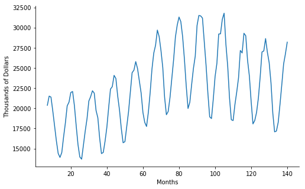

```python
#Creating a figure
fig, ax = plt.subplots()
fig.set_size_inches(8,5)

#Plotting the data
ax.plot(ConstDf['Month'], ConstDf['Public Construction'])
ax.set_ylabel('Thousands of Dollars')
ax.set_xlabel('Months')
ax.spines['right'].set_visible(False)
ax.spines['top'].set_visible(False)
plt.show()
```

The data appears to be cyclical rather than linear, therefore a moving average column will be made.

```python
ConstDf['MovAvg'] = np.NaN
ConstDf['sqErr'] = np.NaN
# Chaging the DataFrame index to DatetimeIndex data type is required for using one of the functions below
ConstDf.index = pd.DatetimeIndex(freq='m', start=pd.Timestamp(year=2002, month=1, day=31), periods = len(ConstDf['Month']))

window = 12
window = window - window % 2

for i in range(int(window/2),ConstDf.shape[0]-int(window/2)):
    ConstDf.loc[ConstDf.index[i],'MovAvg'] = (0.5*ConstDf.iloc[i - int(window/2)]['Public Construction'] + ConstDf.iloc[i - int(window/2)+1:i + int(window/2)]['Public Construction'].sum() + 0.5*ConstDf.iloc[i + int(window/2)]['Public Construction'])/float(window)

ConstDf['sqErr'] = (ConstDf['Public Construction'] - ConstDf['MovAvg'])**2
ConstDf.dropna(how='any',inplace=True)
```

Plotting the 12-month moving average shows the smoothed data and makes the cycle more obvious.

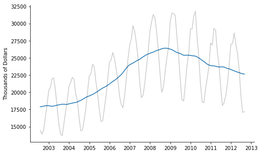

```python
fig,ax = plt.subplots()
fig.set_size_inches(8,5)

ax.plot(ConstDf['MovAvg'],label='Moving Avg')
ax.plot(ConstDf['Public Construction'],label='Public Construction', color='k', alpha=0.2)
ax.set_ylabel('Thousands of Dollars')
ax.xaxis.set_major_locator(mdates.YearLocator())
ax.spines['right'].set_visible(False)
ax.spines['top'].set_visible(False)
plt.show()
```

R1 is found by subtracting the moving average from the actual public construction spending

```python
ConstDf['R1'] = ConstDf['Public Construction'] - ConstDf['MovAvg']
ConstDf['R1Error'] = abs((ConstDf['Public Construction'] - ConstDf['R1'])/ConstDf['Public Construction'])
ConstDf.style.format({
    'MovAvg': '{:.1f}'.format,
    'sqErr': '{:,.1f}'.format,
    'R1': '{:,.1f}'.format,
    'R1Error': '{:,.3f}'.format
})
ConstDf.head()
```

|  | Month | Month-Year | Total Construction | Private Construction | Public Construction | MovAvg | R1 | R1Error | C | R2 | R2X | R2Error | R2ErrorX | fit | sqErr |
| --- | --- | --- | --- | --- | --- | --- | --- | --- | --- | --- | --- | --- | --- | --- | --- |
| 2002-07-31 | 13 | Jan-03 | 59877 | 45473 | 14404 | 17888.666667 | -3484.666667 | 1.241924 | -9320.060606 | 1400.643939 | 0.030802 | 0.030802 | 6.773615e-07 | 44072.356061 | 1.214290e+07 |
| 2002-08-31 | 14 | Feb-03 | 58526 | 44620 | 13906 | 17923.500000 | -4017.500000 | 1.288904 | -9760.712121 | 613.170455 | 0.013742 | 0.013742 | 3.079797e-07 | 44006.829545 | 1.614031e+07 |
| 2002-09-30 | 15 | Mar-03 | 64506 | 49996 | 14510 | 17971.000000 | -3461.000000 | 1.238525 | -4203.363636 | -63.636364 | -0.001273 | 0.001273 | 2.545862e-08 | 50059.636364 | 1.197852e+07 |
| 2002-10-31 | 16 | Apr-03 | 69638 | 53195 | 16444 | 18026.166667 | -1582.166667 | 1.096215 | -1459.571970 | -166.761364 | -0.003135 | 0.003135 | 5.893236e-08 | 53361.761364 | 2.503251e+06 |
| 2002-11-30 | 17 | May-03 | 74473 | 56286 | 18187 | 18052.208333 | 134.791667 | 0.992589 | 1697.541667 | -789.250000 | -0.014022 | 0.014022 | 2.491230e-07 | 57075.250000 | 1.816879e+04 |

```python
print('Mean Squared Error: ', ConstDf['sqErr'].mean())
```

```
Mean Squared Error:  13336345.672558054
```

Plotting the residuals that are yet to be decomposed

```
Average Residual:  -70.8401639344262
```

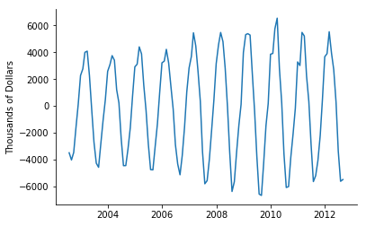

```python
fig,ax = plt.subplots()
ax.plot(ConstDf['R1'])
ax.set_ylabel('Thousands of Dollars')
ax.spines['right'].set_visible(False)
ax.spines['top'].set_visible(False)
print('Average Residual: ', sum(ConstDf['R1'])/len(ConstDf))
```

An autocorrelation analysis detects that there is a cyclical pattern that is repeated every 12 months

```python
maxCorr = 0.0
period = np.NaN
for i in range(1,37):
    corr = ConstDf['R1'].autocorr(lag=i)
    print('Correlation, lag ',i,'   ',corr)
    if corr > maxCorr:
        maxCorr = corr
        period = i
print('period = ',period,'     Maximum Correlation = ',maxCorr)
```

```
Correlation, lag  1     0.8483439693764583
Correlation, lag  2     0.4794202002474209
Correlation, lag  3     -0.015713166591548255
Correlation, lag  4     -0.5042292004159723
Correlation, lag  5     -0.842377863156168
Correlation, lag  6     -0.9633791135039868
Correlation, lag  7     -0.8433426795738449
Correlation, lag  8     -0.49660349404205745
Correlation, lag  9     0.0014819784643012636
Correlation, lag  10     0.4877835886271784
Correlation, lag  11     0.8480483128483884
Correlation, lag  12     0.9885165843674653
Correlation, lag  13     0.8424541086145325
Correlation, lag  14     0.4817265787899667
Correlation, lag  15     -0.01363743624238626
Correlation, lag  16     -0.49848440476124156
Correlation, lag  17     -0.834715231431862
Correlation, lag  18     -0.9588342551126271
Correlation, lag  19     -0.8419481940640743
Correlation, lag  20     -0.49998442203532023
Correlation, lag  21     -0.009926413870266692
Correlation, lag  22     0.47374198586703054
Correlation, lag  23     0.8403617326145203
Correlation, lag  24     0.9807791102503852
Correlation, lag  25     0.8478123446098269
Correlation, lag  26     0.4912669509148241
Correlation, lag  27     -0.007452020649972714
Correlation, lag  28     -0.49034004559790945
Correlation, lag  29     -0.8279281626350435
Correlation, lag  30     -0.9587960676559611
Correlation, lag  31     -0.8498324648391256
Correlation, lag  32     -0.5127437202412763
Correlation, lag  33     -0.02336674160350344
Correlation, lag  34     0.4674960309752109
Correlation, lag  35     0.83299475417013
Correlation, lag  36     0.9768680492926527
period =  12      Maximum Correlation =  0.9885165843674653
```

Each individual 12-month cycle within the time series is plotted along with an average of all of the cycles

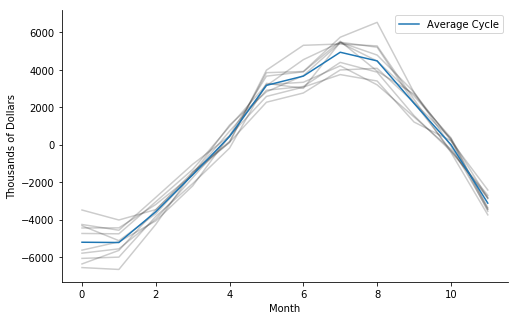

```python
cycleLen = period
numCycles = int(len(ConstDf)/cycleLen + 0.5)
cycles = [ConstDf.iloc[range(i*period,min((i+1)*period,len(ConstDf)))]['R1'] for i in range(numCycles)]
ptsInCycles = [ConstDf.iloc[range(i,len(ConstDf['R1']),period)]['R1'].tolist() for i in range(period)]
avg = [sum(pts)/len(pts) for pts in ptsInCycles]

fig,ax = plt.subplots()
fig.set_size_inches(8,5)

for i in range(len(cycles)):
    ax.plot(cycles[i].values,label='Cycle '+str(i),c='k', alpha=0.2)
AvgCyc = ax.plot(avg,label='Average Cycle')
ax.set_xlabel('Month')
ax.set_ylabel('Thousands of Dollars')
ax.spines['right'].set_visible(False)
ax.spines['top'].set_visible(False)
ax.legend(handles=AvgCyc)
```

A value for the cyclicality is computed and then plotted alongside $R1$

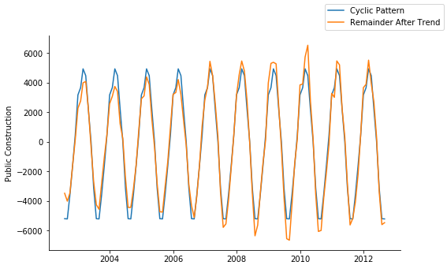

```python
cycleLen = period
numCycles = int(len(ConstDf)/cycleLen + 0.5)
ConstDf['C'] = np.NaN   # Creates an empty column for the cyclicality component data
for i in range(len(ConstDf)):
    ConstDf.loc[ConstDf.index[i], 'C'] = avg[i % cycleLen]

fig,ax = plt.subplots()
fig.set_size_inches(8,5)
ax.plot(ConstDf['C'],label='Cyclic Pattern')
ax.plot(ConstDf['R1'],label='Remainder After Trend')
ax.set_ylabel('Public Construction')
ax.spines['right'].set_visible(False)
ax.spines['top'].set_visible(False)
fig.legend()
plt.show()
```

The code cell below does these:

- Computes the remaining residual construction spending to be explained, $R2$, after subtracting the cyclical component, $C \left( m \right)$: this is the $\epsilon \left( m \right)$ in our model.
- Computes the error, $R2$, as a percentage of the demand time series.
- Computes the mathematical model 'fit', composed of the trend and cyclical components: $T\left( m \right) + C\left( m \right)$.
- Plots the fit of the model $T\left( m \right) + C\left( m \right)$ with the original data, $H \left( m \right)$.
- Computes the average absolute error of $R2Error$ of the original demand time series.
- Removes the sqErr column because it is no longer needed

```
Average Error:  0.023865576696904922
            Month Month-Year  Total Construction  Private Construction  \
2002-07-31     13     Jan-03               59877                 45473
2002-08-31     14     Feb-03               58526                 44620
2002-09-30     15     Mar-03               64506                 49996
2002-10-31     16     Apr-03               69638                 53195
2002-11-30     17     May-03               74473                 56286
2002-12-31     18     Jun-03               80377                 60076
2003-01-31     19     Jul-03               82971                 62216
2003-02-28     20     Aug-03               85191                 63234
2003-03-31     21     Sep-03               83841                 61767
2003-04-30     22     Oct-03               83133                 62813
2003-05-31     23     Nov-03               77915                 60115
2003-06-30     24     Dec-03               71050                 55584
2003-07-31     25     Jan-04               64934                 50975
2003-08-31     26     Feb-04               64138                 50449
2003-09-30     27     Mar-04               73238                 57796
2003-10-31     28     Apr-04               78354                 61177
2003-11-30     29     May-04               83736                 65027
2003-12-31     30     Jun-04               89932                 69039
2004-01-31     31     Jul-04               93614                 72170
2004-02-29     32     Aug-04               96164                 74001
2004-03-31     33     Sep-04               92538                 70662
2004-04-30     34     Oct-04               90582                 70856
2004-05-31     35     Nov-04               86394                 67585
2004-06-30     36     Dec-04               77733                 61438
2004-07-31     37     Jan-05               71474                 57094
2004-08-31     38     Feb-05               72048                 57531
2004-09-30     39     Mar-05               81345                 65425
2004-10-31     40     Apr-05               85485                 67829
2004-11-30     41     May-05               92959                 72862
2004-12-31     42     Jun-05               99632                 77258
...           ...        ...                 ...                   ...
2010-03-31    105     Sep-10               74764                 42978
2010-04-30    106     Oct-10               73470                 45539
2010-05-31    107     Nov-10               68019                 42805
2010-06-30    108     Dec-10               60202                 38928
2010-07-31    109     Jan-11               50955                 32377
2010-08-31    110     Feb-11               50544                 32069
2010-09-30    111     Mar-11               56536                 36074
```

[output cut: 199 more lines]

```
2011-08-31  18449.689394
2011-09-30  19978.429167
2011-10-31  21850.079167
2011-11-30  23848.741667
2011-12-31  26483.737500
2012-01-31  26874.991667
2012-02-29  28053.354167
2012-03-31  27485.154167
2012-04-30  25135.087500
2012-05-31  22862.141667
2012-06-30  19636.125000
2012-07-31  17474.215909
2012-08-31  17426.731061

[122 rows x 14 columns]
```

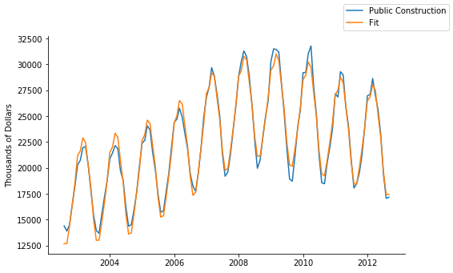

```python
ConstDf['R2'] = ConstDf['R1'] - ConstDf['C']
ConstDf['R2ErrorX'] = ConstDf['R2']/ConstDf['Public Construction']
ConstDf['R2Error'] = abs(ConstDf['R2']/ConstDf['Public Construction'])
ConstDf['R2X'] = ConstDf['R2Error']/ConstDf['Public Construction']
ConstDf['fit'] = ConstDf['MovAvg'] + ConstDf['C']
ConstDf.drop(['sqErr'],axis=1,inplace=True)
print('Average Error: ', sum(ConstDf['R2Error'])/len(ConstDf))
print(ConstDf)

fig,ax = plt.subplots()
fig.set_size_inches(8,5)
ax.plot(ConstDf['Public Construction'],label='Public Construction')
ax.plot(ConstDf['fit'], label = 'Fit')
ax.set_ylabel('Thousands of Dollars')
ax.spines['right'].set_visible(False)
ax.spines['top'].set_visible(False)
fig.legend()
plt.show()
```

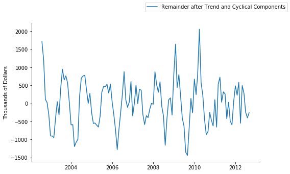

```
Correlation, lag  1     0.6106541481148527
Correlation, lag  2     0.29317633214110433
Correlation, lag  3     0.032738466697920486
Correlation, lag  4     -0.34759664398553447
Correlation, lag  5     -0.5344508663752859
Correlation, lag  6     -0.6230006506956208
Correlation, lag  7     -0.646088070037301
Correlation, lag  8     -0.4194658624427264
Correlation, lag  9     -0.08321481214113124
Correlation, lag  10     0.11094348945158197
Correlation, lag  11     0.4556155226149486
Correlation, lag  12     0.5987593976918467
Correlation, lag  13     0.4610352589007685
Correlation, lag  14     0.46185064070223514
Correlation, lag  15     0.16442405803381963
Correlation, lag  16     -0.11127971905995447
Correlation, lag  17     -0.26562662063789855
Correlation, lag  18     -0.43069364068630656
Correlation, lag  19     -0.48603839868752213
Correlation, lag  20     -0.35449088843719023
Correlation, lag  21     -0.20300403232721936
Correlation, lag  22     -0.0057096459882464805
Correlation, lag  23     0.3003143764233208
Correlation, lag  24     0.2845939814248407
Correlation, lag  25     0.36412860329255964
Correlation, lag  26     0.40545863305329943
Correlation, lag  27     0.13683488346355718
Correlation, lag  28     0.03432829801589051
Correlation, lag  29     -0.0882830380288385
Correlation, lag  30     -0.21346495993138787
Correlation, lag  31     -0.28372559798250585
Correlation, lag  32     -0.27708776483427217
Correlation, lag  33     -0.3074612609231193
Correlation, lag  34     -0.15058711214616466
Correlation, lag  35     -0.004459487763015559
Correlation, lag  36     -0.012838246020215492
period =  1      Maximum Correlation =  0.6106541481148527
```

```python
fig,ax = plt.subplots()
fig.set_size_inches(8,5)
ax.plot(ConstDf['R2'],label='Remainder after Trend and Cyclical Components')
ax.set_ylabel('Thousands of Dollars')
ax.spines['right'].set_visible(False)
ax.spines['top'].set_visible(False)
fig.legend()
plt.show()

maxCorr = 0.0
period = np.NaN
for i in range(1,37):
    corr = ConstDf['R2'].autocorr(lag=i)
    print('Correlation, lag ',i,'   ',corr)
    if corr > maxCorr:
        maxCorr = corr
        period = i
print('period = ',period,'     Maximum Correlation = ',maxCorr)
```

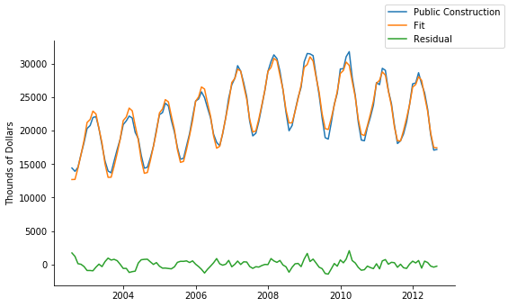

```python
fig,ax = plt.subplots()
fig.set_size_inches(8,5)
ax.plot(ConstDf['Public Construction'],label='Public Construction')
ax.plot(ConstDf['fit'],label='Fit')
ax.plot(ConstDf['R2'],label='Residual')
ax.set_ylabel('Thounds of Dollars')
ax.spines['right'].set_visible(False)
ax.spines['top'].set_visible(False)
fig.legend()
plt.show()
```